# Lab 6

# Lasso pipeline and lambda tuning Inter

```python
lasso_pipeline_4 = Pipeline(
  [("preprocessing", ct3),
  ("interaction", ct_inter),
  ("lasso_regression", Lasso())]
)

lambdas = {'lasso_regression__alpha': [0.01, 0.1, 1, 10, 100, 500]}

lambda_tuning(lasso_pipeline_4, lambdas)
```

```
array([ 0.29114614,  0.2932067 ,  0.30176037,  0.40260437,  0.30583131,
       -0.04320472])
```

# Lasso pipeline (L=10)

```python
lasso_pipeline_2 = Pipeline(
  [("preprocessing", ct3),
  ("interaction", ct_inter),
  ("lasso_regression", Lasso(alpha = 10))]
)

(-1*cross_val_score(lasso_pipeline_2, X, y, cv = 5, scoring = 'neg_mean_squared_error')).mean()
```

```
np.float64(116332.70937176762)
```

# Elastic pipeline and lambda tuning CRuns

```python
elastic_pipeline_2 = Pipeline(
  [("preprocessing", ct1),
  ("elastic_regression", ElasticNet())]
)

lambdas = {'elastic_regression__alpha': [0.001, 0.01, 0.1, 1, 10], 'elastic_regression__l1_ratio': [0.001, 0.01, 0.1, 0.5, 0.8]}

elastic_lambda_tuning(elastic_pipeline_2, lambdas)
```

```
alpha_l1ratio    (0.1, 0.5)
scores             0.293485
Name: 13, dtype: object
```

# ElasticNet pipeline (L=0.1, A=0.5)

```python
elastic_pipeline_2 = Pipeline(
  [("preprocessing", ct1),
  ("elastic_regression", ElasticNet(alpha = 0.1, l1_ratio=0.5))]
)

(-1*cross_val_score(lasso_pipeline_2, X, y, cv = 5, scoring = 'neg_mean_squared_error')).mean()
```

```
np.float64(116332.70937176762)
```

# Elastic pipeline and lambda tuning Top 5

```python
elastic_pipeline_3 = Pipeline(
  [("preprocessing", ct2),
  ("elastic_regression", ElasticNet())]
)

lambdas = {'elastic_regression__alpha': [0.001, 0.01, 0.1, 1, 10], 'elastic_regression__l1_ratio': [0.001, 0.01, 0.1, 0.5, 0.8]}

elastic_lambda_tuning(elastic_pipeline_3, lambdas)
```

```
alpha_l1ratio    (0.01, 0.001)
scores                0.368034
Name: 5, dtype: object
```

# ElasticNet pipeline (L=0.01, A=0.001)

```python
elastic_pipeline_3 = Pipeline(
  [("preprocessing", ct2),
  ("elastic_regression", ElasticNet(alpha = 0.01, l1_ratio=0.001))]
)

(-1*cross_val_score(elastic_pipeline_3, X, y, cv = 5, scoring = 'neg_mean_squared_error')).mean()
```

```
np.float64(126648.11443654809)
```

# Elastic pipeline and lambda tuning Inter

```python
elastic_pipeline_4 = Pipeline(
  [("preprocessing", ct3),
  ("interaction", ct_inter),
  ("elastic_regression", ElasticNet())]
)

lambdas = {'elastic_regression__alpha': [0.001, 0.01, 0.1, 1, 10], 'elastic_regression__l1_ratio': [0.001, 0.01, 0.1, 0.5, 0.8]}

elastic_lambda_tuning(elastic_pipeline_4, lambdas)
```

```
alpha_l1ratio    (1, 0.1)
scores           0.431332
Name: 17, dtype: object
```

# ElasticNet pipeline (L=1, A=0.1)

```python
elastic_pipeline_4 = Pipeline(
  [("preprocessing", ct3),
  ("interaction", ct_inter),
  ("elastic_regression", ElasticNet(alpha = 1, l1_ratio=0.1))]
)

(-1*cross_val_score(elastic_pipeline_4, X, y, cv = 5, scoring = 'neg_mean_squared_error')).mean()
```

```
np.float64(112491.93140942996)
```

# Results

The Ridge interaction model and the Elastic interaction model both return MSE scores of ~112000.

# A

The coefficients in the Ridge models are far smaller than the original model, by almost a factor of 10, which makes sense because ridge tries to balance SSE while keeping the Betas small.

```python
print("Original Coefs")
print(coefs1)
print("Ridge Coefs")
print(coefs2)
```

```
Original Coefs
                 feature  coefficient
0      dummify__League_A   -31.299712
1      dummify__League_N    31.299712
2    dummify__Division_E    58.424623
3    dummify__Division_W   -58.424623
4   dummify__NewLeague_A    12.381163
5   dummify__NewLeague_N   -12.381163
6     standardize__AtBat  -291.094556
7      standardize__Hits   337.830479
8     standardize__HmRun    37.853837
9      standardize__Runs   -60.572479
10      standardize__RBI   -26.994984
11    standardize__Walks   135.073897
12    standardize__Years   -16.693359
```

[output cut: 33 more lines]

# B

For each of my Lasso models I got a lambda of 10 except for the Top 5 model which found a lambda of 1 was best. This makes sense because the data doesn’t change, only the model params which themselves are standardized. I got differing MSE values however which also makes sense because the differences in the models will affect how well they predict salary on future data.

```python
print("Lasso Original MSE")
print((-1*cross_val_score(lasso_pipeline_1, X, y, cv = 5, scoring = 'neg_mean_squared_error')).mean())
print("Lasso CRuns MSE")
print((-1*cross_val_score(lasso_pipeline_2, X, y, cv = 5, scoring = 'neg_mean_squared_error')).mean())
print("Lasso Top 5 MSE")
print((-1*cross_val_score(lasso_pipeline_3, X, y, cv = 5, scoring = 'neg_mean_squared_error')).mean())
print("Lasso Inter MSE")
print((-1*cross_val_score(lasso_pipeline_4, X, y, cv = 5, scoring = 'neg_mean_squared_error')).mean())
```

```
Lasso Original MSE
121828.14133338635
Lasso CRuns MSE
116332.70937176762
Lasso Top 5 MSE
127187.74346481934
Lasso Inter MSE
131752.39380734757
```

# C

```python
print("Ridge Original MSE")
print((-1*cross_val_score(ridge_pipeline_1, X, y, cv = 5, scoring = 'neg_mean_squared_error')).mean())
print("Lasso Original MSE")
print((-1*cross_val_score(lasso_pipeline_1, X, y, cv = 5, scoring = 'neg_mean_squared_error')).mean())
print("Elastic Original MSE")
print((-1*cross_val_score(elastic_pipeline_1, X, y, cv = 5, scoring = 'neg_mean_squared_error')).mean())
print("Ridge Inter MSE")
print((-1*cross_val_score(ridge_pipeline_4, X, y, cv = 5, scoring = 'neg_mean_squared_error')).mean())
print("Lasso Inter MSE")
print((-1*cross_val_score(lasso_pipeline_4, X, y, cv = 5, scoring = 'neg_mean_squared_error')).mean())
print("Elastic Inter MSE")
print((-1*cross_val_score(elastic_pipeline_4, X, y, cv = 5, scoring = 'neg_mean_squared_error')).mean())
```

```
Ridge Original MSE
120716.43558937623
Lasso Original MSE
121828.14133338635
Elastic Original MSE
121760.922840516
Ridge Inter MSE
112278.23780506244
Lasso Inter MSE
131752.39380734757
Elastic Inter MSE
112491.93140942996
```

# Final Model

```python
final_fit_model = elastic_pipeline_4.fit(X, y)
feature_names = final_fit_model.named_steps['interaction'].get_feature_names_out()
coefs = final_fit_model.named_steps["elastic_regression"].coef_

coef_df = pd.DataFrame({
    'feature': feature_names,
    'coefficient': coefs
})

coef_df
```

|  | feature | coefficient |
| --- | --- | --- |
| 0 | interaction__1 | 0.000000 |
| 1 | interaction__standardize__CRuns | 71.987042 |
| 2 | interaction__standardize__Hits | 57.563080 |
| 3 | interaction__standardize__AtBat | 43.130567 |
| 4 | interaction__standardize__CAtBat | 60.735998 |
| 5 | interaction__standardize__CWalks | 64.605424 |
| 6 | interaction__dummify__Division_W | -23.830392 |
| 7 | interaction__standardize__CRuns standardize__Hits | 23.170968 |
| 8 | interaction__standardize__CRuns standardize__A... | 15.196684 |
| 9 | interaction__standardize__CRuns standardize__C... | -6.272737 |
| 10 | interaction__standardize__CRuns standardize__C... | -0.671010 |
| 11 | interaction__standardize__CRuns dummify__Divis... | 15.359011 |
| 12 | interaction__standardize__Hits standardize__AtBat | 40.154369 |
| 13 | interaction__standardize__Hits standardize__CA... | 13.506889 |
| 14 | interaction__standardize__Hits standardize__CW... | 22.578656 |
| 15 | interaction__standardize__Hits dummify__Divisi... | 3.404511 |
| 16 | interaction__standardize__AtBat standardize__C... | 9.068806 |
| 17 | interaction__standardize__AtBat standardize__C... | 15.609939 |
| 18 | interaction__standardize__AtBat dummify__Divis... | 4.837280 |
| 19 | interaction__standardize__CAtBat standardize__... | -18.874317 |
| 20 | interaction__standardize__CAtBat dummify__Divi... | 13.009757 |
| 21 | interaction__standardize__CWalks dummify__Divi... | 10.940602 |

In the final ElasticNet model (L = 1, A = 0.1) the most influential variables for predicting player salary are career runs (CRuns), career walks (CWalks), career at-bats (CAtBat), at bats, and hits, along with their interaction effects. Players with stronger long-term batting performance (especially higher CRuns and CWalks) tend to earn higher salaries. Division (East vs West) still shows a smaller but noticeable influence. Overall, the model highlights that career consistency and offensive productivity are the strongest indicators of player pay, rather than recent or single-season stats.

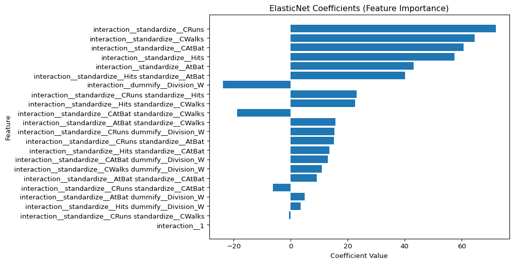

```python
coef_df["abs_coef"] = coef_df["coefficient"].abs()
coef_sorted = coef_df.sort_values("abs_coef", ascending=False)

plt.figure(figsize=(8,6))
plt.barh(coef_sorted["feature"], coef_sorted["coefficient"])
plt.title("ElasticNet Coefficients (Feature Importance)")
plt.xlabel("Coefficient Value")
plt.ylabel("Feature")
plt.gca().invert_yaxis()
plt.show()
```